# Discriminant Analysis_CW

```r
library(MASS) # This package contains the LDA function
library(tidyverse)
library(ROCR)# to plot the ROC curve
library(caret) # for Discriminant Analysis
library(ISLR2)
set.seed(1234) # For reproducibility
```

More information on the caret package can be found at this link [Information on Caret Package](https://topepo.github.io/caret/index.html)

We will use the ‘Default’ dataset to predict whether an individual will default credit card payments based on balance, student status and annual income.

Dependent/Target variable: default Independent/predictor variables: balance, student, income

## Data Preprocessing

```r
#Load the data
default_data <- Default
head(default_data)
```

|  | default | student | balance | income |
| --- | --- | --- | --- | --- |
| 1 | No | No | 729.5265 | 44361.625 |
| 2 | No | Yes | 817.1804 | 12106.135 |
| 3 | No | No | 1073.5492 | 31767.139 |
| 4 | No | No | 529.2506 | 35704.494 |
| 5 | No | No | 785.6559 | 38463.496 |
| 6 | No | Yes | 919.5885 | 7491.559 |

```r
#Summary Statistics
summary(default_data)
```

```
 default    student       balance
 No :9667   No :7056   Min.   :   0.0
 Yes: 333   Yes:2944   1st Qu.: 481.7
                       Median : 823.6
                       Mean   : 835.4
                       3rd Qu.:1166.3
                       Max.   :2654.3
     income
 Min.   :  772
 1st Qu.:21340
 Median :34553
 Mean   :33517
 3rd Qu.:43808
 Max.   :73554
```

Plot the data

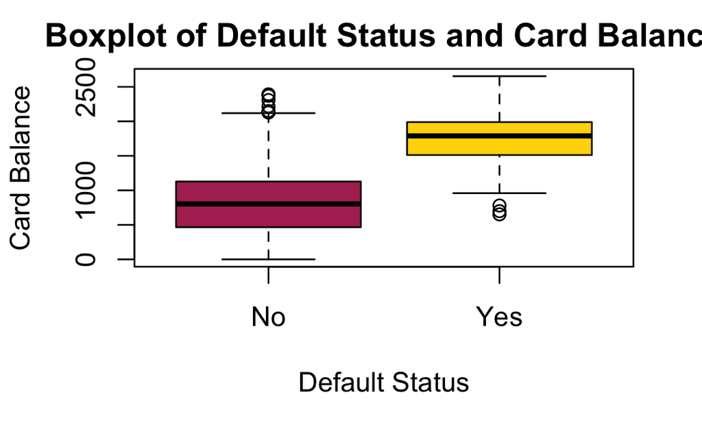

```r
boxplot(balance ~ default, data = default_data, main = "Boxplot of Default Status and Card Balance", xlab = "Default Status", ylab = "Card Balance", col = c("maroon", "gold"))
```

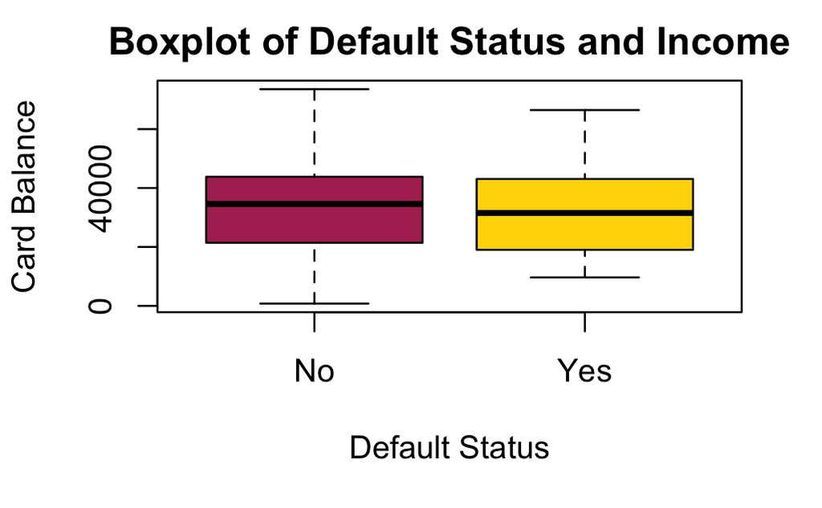

```r
boxplot(income ~ default, data = default_data, main = "Boxplot of Default Status and Income", xlab = "Default Status", ylab = "Card Balance", col = c("maroon", "gold"))
```

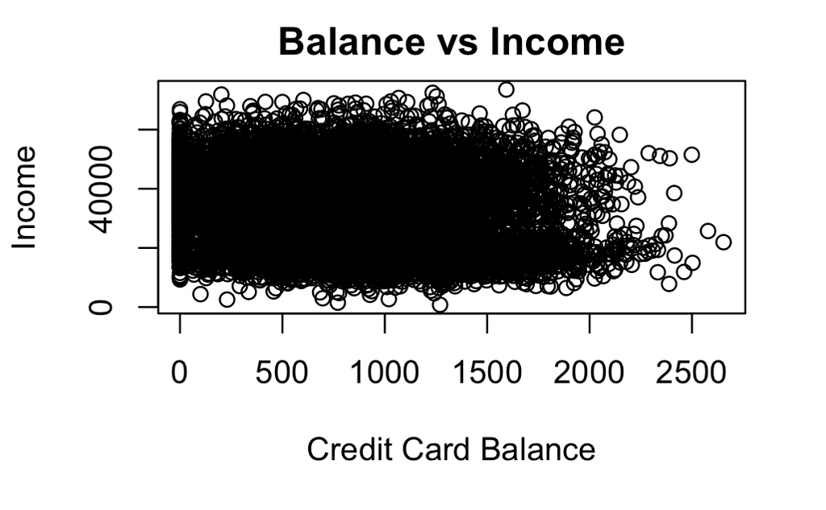

```r
plot(income ~ balance, data = default_data, main = "Balance vs Income", xlab = "Credit Card Balance", ylab = "Income")
```

Training and Test Datasets

Split the data into training and testing datasets. Training observations are used to build the model. We want the model to perform well not only on the training observations but also on new data (which we call the test data). If separate training and test datasets are not available, we will hold out a portion of the data (e.g. 20 or 25% of the available data) for testing the model. We will use the createDataPartition() tool from the caret package to split the data

```r
#Create a training set using 80% of the data
intrain <- createDataPartition(y = default_data$default, p=0.8, list = FALSE)
train_data <- default_data[intrain,]
test_data <- default_data[-intrain,]
```